# Plotting brain atlases in ggplot

## Introduction

Plotting areas from different brain atlases ggplot2 is a handy way of displaying results or grouping of aparc data.

## Basic use

The function `ggseg()`, is based in the ggplot2 format, it is recommended to get a little familiarized with with [plotting data with ggplot2](http://r-statistics.co/Complete-Ggplot2-Tutorial-Part1-With-R-Code.html).

Out-of-the-box, ggseg() works without supplying any extra information. It will create a base plot of the aparc brain segmentations.

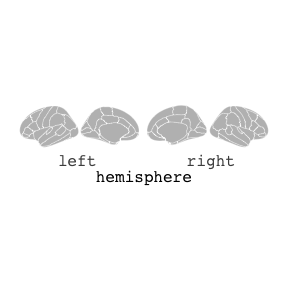

```r
library(ggseg)
library(ggplot2)
ggseg()
```

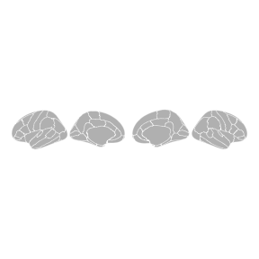

```r
ggseg() + theme_void()
```

You can supply some extra options to ggseg, to alter the plot as you wish.

You can stack the hemispheres if you want

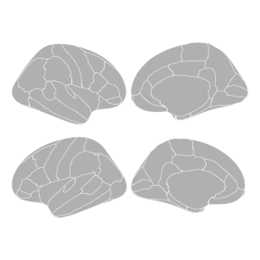

```r
ggseg(position="stacked") +
  theme_void()
```

Maybe you want each area to have a different colour. ggseg has a built column called `area` wich you can use as fill to achieve this. **Note:** unlike other ggplots, before using `aes` you must indicate `mapping=aes`.

[figure not shown]

```r
ggseg(mapping=aes(fill=area)) +
  theme_void()
```

Maybe you also want the contour lines to be black rather than white, and also a little thicker?

[figure not shown]

```r
ggseg(colour="black", size=.7, mapping=aes(fill=area)) +
  theme_void()
```

You can also zoom in on a single area and plot it alone.

[figure not shown]

```r
ggseg(plot.area="superior frontal") +
  theme_void()
```

Or you can plot several of them, despite not making much sense.

[figure not shown]

```r
ggseg(plot.area=c("transverse temporal", "insula","pre central","superior parietal")) +
  theme_void()
```

You can also choose to only view one of the hespheres by adding the `hemisphere` option

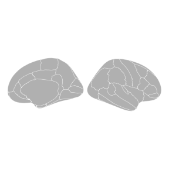

```r
ggseg(hemisphere="right") +
  theme_void()
```

If you want to plot the entire brain, but hightlight specific areas with colour, you will need to provide the function with some data. The data **must** include a column names `area`, with area names corresponding to that of the aparc segmentations. Here we create some data with 4 rows, and an `area` and `p` column. We provide the `p` column as the column that dictates the colour of the area.

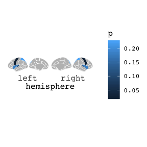

```r
someData = data.frame(
  area = c("transverse temporal", "insula",
           "pre central","superior parietal"),
  p = sample(seq(0,.5,.001), 4),
  stringsAsFactors = FALSE)

ggseg(data=someData, mapping=aes(fill=p))
```

We can also change how this looks, by various ggplot functions

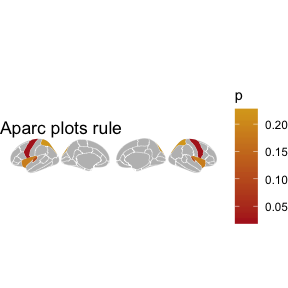

```r
ggseg(data=someData, mapping=aes(fill=p)) +
  theme_void() +
  scale_fill_gradient(low="firebrick",high="goldenrod") +
  labs(title="Aparc plots rule")
```

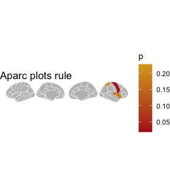

```r
someData$hemi = "right"

ggseg(data=someData, mapping=aes(fill=p)) +
  theme_void() +
  scale_fill_gradient(low="firebrick",high="goldenrod") +
  labs(title="Aparc plots rule")
```

If your data has different statistics for different groups, and you want to plot them all, we can use ggplot’s `facet_wrap` or `facet_grid` for that. The data needs to be in long format for this to work, like ggplot likes it.

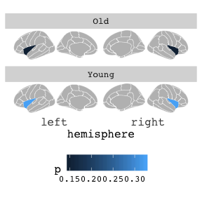

```r
someData = data.frame(
  area = rep(c("transversetemporal", "insula",
               "precentral","superiorparietal"),2),
  p = sample(seq(0,.5,.001), 8),
  AgeG = c(rep("Young",4), rep("Old",4)),
  stringsAsFactors = FALSE)

ggseg(data=someData, mapping=aes(fill=p)) +
  facet_wrap(~AgeG, ncol=1) +
  theme(legend.position = "bottom")
```

We can change how this looks quite a bit. Maybe you want it on a dark background, and the areas without any data to be transparent?

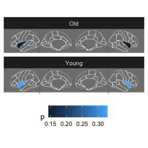

```r
ggseg(data=someData, na.fill = "transparent",mapping=aes(fill=p)) +
  facet_wrap(~AgeG, ncol=1) +
  theme_dark() +
  theme(legend.position = "bottom",
        axis.text = element_blank(),
        axis.title = element_blank()
        )
```

You can try other atlases too.

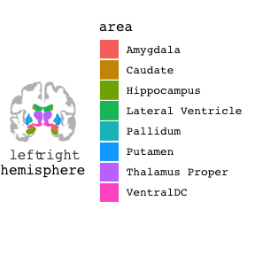

```r
ggseg(atlas="aseg", mapping=aes(fill=area))
```